# Series_atv1

Ana Godoy

4/25/2018

## Faremos uma an??lise das s??ries Black Mirror, Sherlock, American Horror Story e Penny Dreadful

```r
series = read_csv(here("data/series_from_imdb.csv"),
                    progress = FALSE,
                    col_types = cols(.default = col_double(),
                                     series_name = col_character(),
                                     episode = col_character(),
                                     url = col_character(),
                                     season = col_character())) %>%
    filter(series_name %in% c("Black Mirror", "Sherlock", "American Horror Story", "Penny Dreadful"))
```

## a) Qual das s??ries que voc?? escolheu ?? mais bem avaliada no IMDB? A diferen??a ?? grande? Pequena? Muda de acordo com as temporadas da s??rie?

Para responder essa pergunta, primeiro tentaremos visualizar a distribui????o dos votos dos usu??rios e avalia????es por s??rie. Podemos ver nos gr??ficos abaixo a distribui????o entre a quantidade de notas e as avalia????es dadas para cada s??rie, podemos tamb??m destacar que Black Mirror e Sherlock possuem uma maior quantidade de avalia????es se compararmos com American Horror Story e Penny Dreadful.

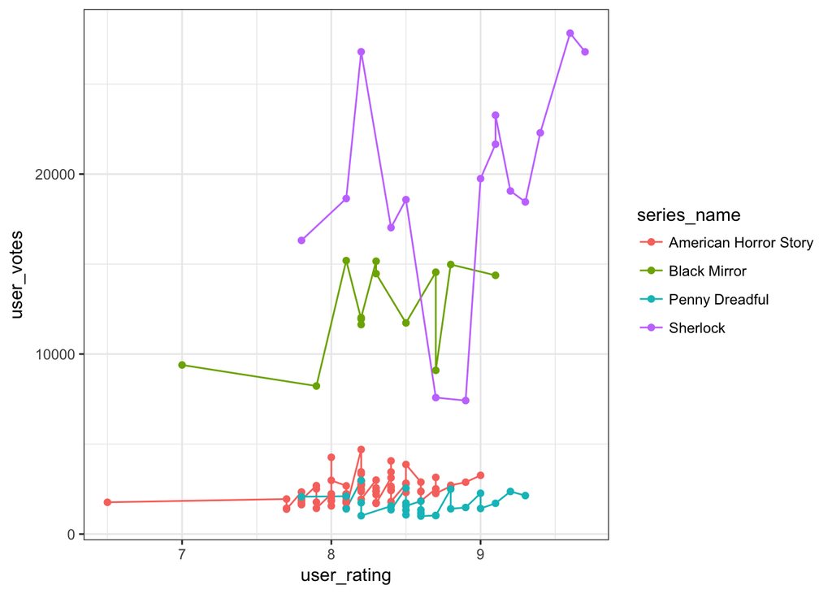

```r
series %>%
  ggplot(aes(x = user_rating, y = user_votes, color = series_name)) +
  geom_line() +
  geom_point()
```

Aqui podemos notar que Sherlock pode ser considerada a mais bem avaliada no IMDB, por possuir maior m??dia de votos e uma melhor m??dia de avalia????es.

```r
series %>%
    group_by(series_name) %>%
    summarise(media_avaliacao = mean(user_rating),
              media_votos = mean(user_votes))
```

```
## # A tibble: 4 x 3
##             series_name media_avaliacao media_votos
##                   <chr>           <dbl>       <dbl>
## 1 American Horror Story        8.198630    2421.370
## 2          Black Mirror        8.307692   12519.846
## 3        Penny Dreadful        8.585185    1669.481
## 4              Sherlock        8.866667   19429.733
```

## Qual das s??ries que voc?? escolheu tem epis??dios de qualidade mais irregular segundo o IMDB? A diferen??a ?? grande? Pequena?

```r
series %>%
    group_by(series_name) %>%
    summarise(media_avaliacao = mean(user_rating),
              dp_avaliacao = sd(user_rating), coef_variacao = media_avaliacao/dp_avaliacao)
```

```
## # A tibble: 4 x 4
##             series_name media_avaliacao dp_avaliacao coef_variacao
##                   <chr>           <dbl>        <dbl>         <dbl>
## 1 American Horror Story        8.198630    0.3607450      22.72694
## 2          Black Mirror        8.307692    0.5139091      16.16568
## 3        Penny Dreadful        8.585185    0.3591697      23.90287
## 4              Sherlock        8.866667    0.5665266      15.65093
```